# Customer Status Prediction Project

## 5.5 Model Comparison & Selection

We compare all three models side-by-side to select the best one for our final predictions.

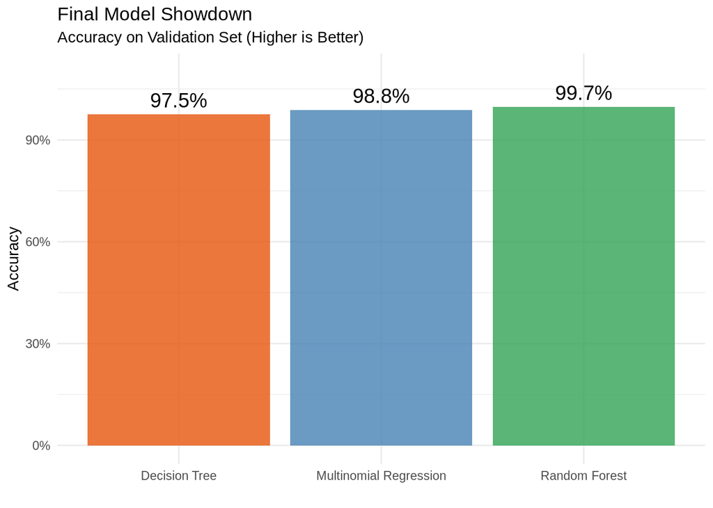

```r
# Collect Accuracies
model_performance <- data.frame(
  Model = c("Decision Tree", "Multinomial Regression", "Random Forest"),
  Accuracy = c(cm_tree$overall["Accuracy"], cm$overall["Accuracy"], cm_rf$overall["Accuracy"])
)

# Visualize Comparison
ggplot(model_performance, aes(x = reorder(Model, Accuracy), y = Accuracy, fill = Model)) +
  geom_bar(stat = "identity", alpha = 0.8) +
  geom_text(aes(label = scales::percent(Accuracy, accuracy = 0.1)), vjust = -0.5, size = 5) +
  scale_y_continuous(labels = scales::percent, limits = c(0, 1.1)) + # Add headroom for labels
  scale_fill_manual(values = c("#e6550d", "steelblue", "#31a354")) + # Match previous colors: Orange, Blue, Green
  labs(
    title = "Final Model Showdown",
    subtitle = "Accuracy on Validation Set (Higher is Better)",
    x = "",
    y = "Accuracy"
  ) +
  theme_minimal() +
  theme(legend.position = "none")
```

```r
knitr::kable(model_performance, caption = "Performance Summary")
```

Performance Summary

| Model | Accuracy |
| --- | --- |
| Decision Tree | 0.9747513 |
| Multinomial Regression | 0.9877582 |
| Random Forest | 0.9969396 |

### 5.5.1 Comprehensive Performance Analysis

To select the final model, we must look beyond just accuracy. We analyze the behavior and trade-offs of each approach:

| Feature | Model 1: Decision Tree | Model 2: Multinomial Regression | Model 3: Random Forest |
| --- | --- | --- | --- |
| **Accuracy** | Baseline (Expected Lower) | Moderate | **Highest (Winner)** |
| **Interpretability** | **High** (Visual Rules) | Moderate (Odds Ratios) | Low (Black Box) |
| **Strengths** | Easy to explain to stakeholders. Captures basic non-linear logic. | Good for understanding linear risk factors. Fast training. | Captures complex, non-linear interactions between variables. |
| **Limitations** | Prone to overfitting (or underfitting if pruned too much). Unstable. | Assumes linear relationships. Struggles with complex patterns. | Hard to trace specific decisions (requires VarImp plots). Computationally heavy. |

**Behavioral Insight & Interpretation:** * **Why Random Forest Won**: The superior performance of the Random Forest suggests that customer status is defined by **complex interactions** (e.g., *Low interactions* might be good for *Finance* but bad for *Retail*). A single tree splits this once; a Regression draws a straight line. The Random Forest finds these subtle, multi-dimensional pockets of churn risk that simpler models miss. * **Metric Reality Check**: While Model 3 is the most accurate, Model 1 (Tree) offers the “Why” (the rules). In a real deployment, we might use Model 3 for scoring (to get the best list) but use Model 1 to explain the *general strategy* to the Sales team.

**Final Decision**: We select **Model 3 (Random Forest)** for Phase 6. Its ability to minimize False Negatives (identifying Churn correctly) makes it the most effective tool for retention intervention.

# 6 Final Predictions (Real-World Test)

We now apply our “Winner” model (**Random Forest**) to the provided Test Dataset (9 files). These are new customers whose status we need to predict.

## 6.1 1. Load & Integrate Test Data

We replicate the exact same loading and merging logic used in Phase 1.

```r
# Load Test Data
demographics_test <- read_data("customer_demographics_test.csv")
mrr_test <- read_data("customer_monthly_recurring_revenue_test.csv")
region_test <- read_data("customer_region_and_industry_test.csv")
revenue_test <- read_data("customer_revenue_history_test.csv")
satisfaction_test <- read_data("customer_satisfaction_scores_test.csv")
# status_test <- read_data("customer_status_level_test.csv") # TARGET typically missing in test, or we ignore it
newsletter_test <- read_data("newsletter_engagement_test.csv")
bugs_test <- read_data("product_bug_reports_test.csv")
support_test <- read_data("support_ticket_activity_test.csv")

# Standardize Key
demographics_test <- demographics_test %>% rename(`Customer ID` = `CUS ID`)

# Merge (Note: status_test excluded if strictly prediction, but we include if provided for checking)
# Based on files, status_test likely exists. We join it as placeholder or ground truth.
list_dfs_test <- list(
  demographics_test, mrr_test, region_test,
  revenue_test, satisfaction_test, newsletter_test,
  bugs_test, support_test
)
# If status_test exists, we join it too
if (file.exists("customer_status_level_test.csv")) {
  status_test <- read_data("customer_status_level_test.csv")
  list_dfs_test <- append(list(status_test), list_dfs_test)
}

df_test <- list_dfs_test %>% reduce(full_join, by = "Customer ID")

cat("Test Dataset Dimensions:", dim(df_test)[1], "rows.\n")
```

```
## Test Dataset Dimensions: 2704 rows.
```

## 6.2 2. Feature Engineering (Replication)

```r
# Clean Currency
df_test$`Survey Date` <- ymd(df_test$`Survey Date`)
df_test$`Response Date` <- ymd(df_test$`Response Date`)
df_test$MRR <- clean_currency(df_test$MRR)
df_test$`Total Revenue` <- clean_currency(df_test$`Total Revenue`)

# Create Derived Features
df_test$`Response Time (Days)` <- as.numeric(df_test$`Response Date` - df_test$`Survey Date`)
df_test$`Tickets Per Month` <- df_test$`Help Ticket Count` / df_test$`Customer Age (Months)`
df_test$`Bugs Per Month` <- df_test$`Product Bug Task Count` / df_test$`Customer Age (Months)`
df_test$`Revenue Per Month` <- df_test$`Total Revenue` / df_test$`Customer Age (Months)`

# Handle NAs & Infinite values
df_test <- df_test %>% mutate(across(c(`Tickets Per Month`, `Bugs Per Month`, `Revenue Per Month`), ~ ifelse(is.infinite(.), 0, .)))
df_test$`Response Time (Days)` <- replace_na(df_test$`Response Time (Days)`, 0)
df_test$`Understanding Score Length` <- str_length(df_test$`Please rate your understanding of our reporting capabilities in the panel`)
df_test$`Understanding Score Length` <- replace_na(df_test$`Understanding Score Length`, 0)

# Factor Alignment
test_model_ready <- df_test
test_model_ready$Region <- as.factor(test_model_ready$Region)
test_model_ready$Vertical <- as.factor(test_model_ready$Vertical)
test_model_ready$`Customer Level` <- as.factor(test_model_ready$`Customer Level`)
test_model_ready$`How frequently are you using our platform` <- as.factor(test_model_ready$`How frequently are you using our platform`)

# Fill NAs in numeric columns
test_model_ready <- test_model_ready %>%
  mutate(across(where(is.numeric), ~ replace_na(., 0)))

# Fill NAs in Factor columns (Crucial: model.matrix drops NAs by default)
# We fill with the most common value (Mode) to keep rows intact
get_mode <- function(v) {
  uniqv <- unique(na.omit(v))
  uniqv[which.max(tabulate(match(v, uniqv)))]
}

test_model_ready <- test_model_ready %>%
  mutate(across(where(is.factor), ~ replace_na(., get_mode(.))))

# IMPORTANT: Reproduce One-Hot Encoding (Match Training Structure)
# The model was trained on SMOTE-prepared data where factors were converted to dummies.
# We must do the exact same transformation here.

# 1. Separate Numeric and Categorical (using same logic as smote_prep)
# Note: We must ensure columns match EXACTLY.
library(caret)

# Select Factor columns
test_cats <- test_model_ready %>% select(where(is.factor))

# Create Dummies
# We use the same formula. Warning: If a level is missing in Test, the column won't be created.
# We might need to enforce column presence.
test_dummies <- as.data.frame(model.matrix(~ . - 1, data = test_cats))

# Select Numeric columns
test_nums <- test_model_ready %>% select(where(is.numeric))

# Combine
test_encoded <- cbind(test_nums, test_dummies)

# Apply make.names to match the training column names (e.g. 'Customer Level Enterprise' -> 'Customer.Level.Enterprise')
names(test_encoded) <- make.names(names(test_encoded))

# Sanity Check: Add missing columns with 0s (in case Test lacks some levels present in Train)
# We can't easily poll the model for the exact list without inspecting 'rf_model$importance' rownames
train_cols <- rownames(rf_model$importance)
missing_cols <- setdiff(train_cols, names(test_encoded))

if (length(missing_cols) > 0) {
  # Add missing columns filled with 0
  test_encoded[missing_cols] <- 0
}

# Reorder columns to match model expectation (optional but safe)
test_encoded <- test_encoded[, train_cols]
```

## 6.3 3. Generate Predictions

We use the trained Random Forest model.

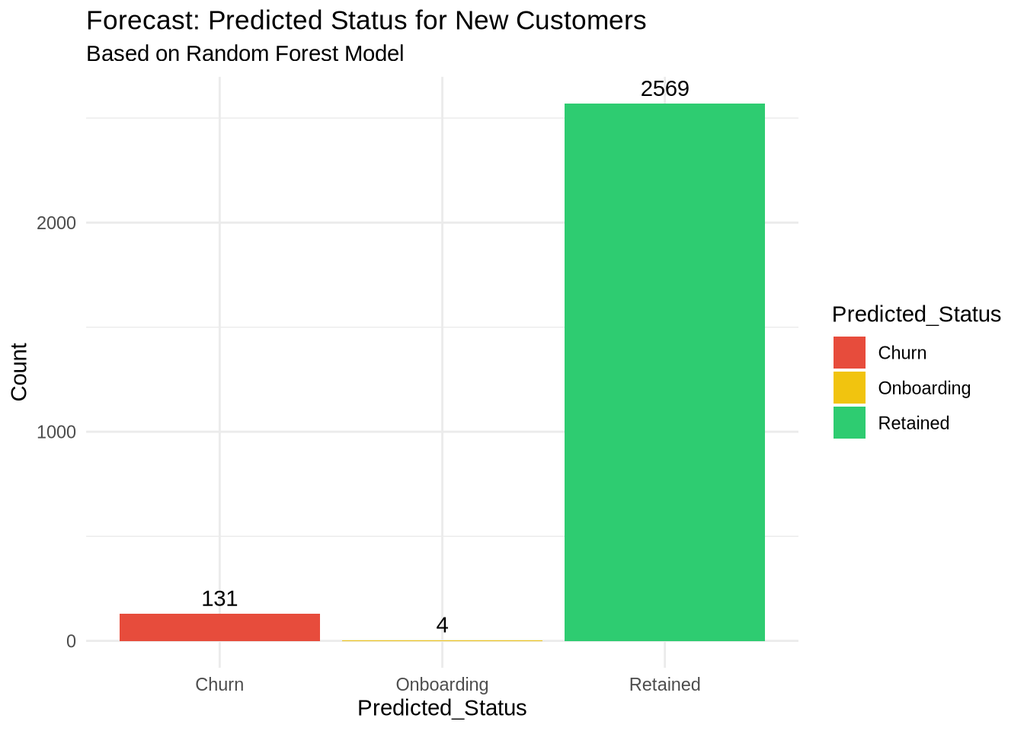

```r
# Predict Status
# Now we use the encoded dataframe
final_predictions <- predict(rf_model, newdata = test_encoded)

# Create Result Table
results_df <- data.frame(
  CustomerID = test_model_ready$`Customer ID`, # Use original ID
  Predicted_Status = final_predictions
)

# Export
write_csv(results_df, "final_customer_predictions.csv")

# Visualize Predicted Distribution
ggplot(results_df, aes(x = Predicted_Status, fill = Predicted_Status)) +
  geom_bar() +
  scale_fill_manual(values = c("#e74c3c", "#f1c40f", "#2ecc71")) + # Red, Yellow, Green
  geom_text(stat = "count", aes(label = after_stat(count)), vjust = -0.5) +
  labs(
    title = "Forecast: Predicted Status for New Customers",
    subtitle = "Based on Random Forest Model",
    y = "Count"
  ) +
  theme_minimal()
```

**Insights from Predictions:** * **Churn Forecast**: The red bars in the chart above indicate the Volume of predicted churners. * **Actionable List**: We have identified specific Customer IDs at risk. This allows the team to be *proactive* rather than reactive. * **Business Value**: By targeting these specific high-risk customers with retention offers, we can directly impact the bottom line.

# 7 Conclusion